# nero

```python
import pandas as pd
import gensim
import seaborn as sns
import matplotlib.pyplot as plt
import numpy as np
```

```python
import nltk
from nltk.tokenize import word_tokenize
```

```python
import re
```

```python
import time
```

```python
from gensim.models import Word2Vec
```

```python
from mpl_toolkits.mplot3d import Axes3D
```

```python
nltk.download('punkt')
```

```
True
```

## word2vec

This notebook involves:

- basic text cleaning
- fitting a word2vec model on the biomedical corpus data using Genism
- perform dimensionality reduction (PCA, t-SNE) on a toy subset of the data and visualize them in 3d
- exploratory analysis on entity columns of the annotation table
  - extracting unique drugs and diseases from the entity columns
  - find out the number of drugs and diseases being represented in word2vec embeddings
  - take the average of single-token embeddings for multi-token diseases or drugs

### Some data preprocessing

- Get individual words from sentences
- Use NLTK to filter out stopwords, punctuation
- Turn the words into vector representations using Word2Vec

```python
f = open("sentence_list.txt")
corpus = f.read()
```

```python
type(corpus)
```

```
str
```

```python
#corpus
```

```python
corpus_ls = corpus.split('\n')
```

```python
corpus_ls[:5]
```

```
['( A) Amph2 SH3 and Amph2-SH3deltaDAPS domains bind equally well to dynamin.',
 '( A) and an NH -terminal deletion mutant  Bcl-2( 1-82) retained Bax binding activity  in vitro  but failed to suppress Bax-mediated cytotoxicity in yeast.',
 '( A) and cephalexin ( B) binding to WT BcII (filled circles) and M5 (open circles).',
 '( A) and competitive binding of V2R-pp and V2R-np to beta-arrestin_2 ( B).',
 '( A) and irreversible ( B) binding of PAC-1  to thrombin-stimulated platelets.']
```

```python
# remove parentheses with alphabetical indices

corpus_ls_re = [re.sub('\(\s[a-zA-Z]+\)', '', x) for x in corpus_ls]

# remove punctuations

corpus_ls_re2 = [re.sub('[\.\,\;]', '', x) for x in corpus_ls_re]
```

```python
corpus_ls_re2[:5]
```

```
[' Amph2 SH3 and Amph2-SH3deltaDAPS domains bind equally well to dynamin',
 ' and an NH -terminal deletion mutant  Bcl-2( 1-82) retained Bax binding activity  in vitro  but failed to suppress Bax-mediated cytotoxicity in yeast',
 ' and cephalexin  binding to WT BcII (filled circles) and M5 (open circles)',
 ' and competitive binding of V2R-pp and V2R-np to beta-arrestin_2 ',
 ' and irreversible  binding of PAC-1  to thrombin-stimulated platelets']
```

```python
# tokenize each sentence in the corpus into words
corpus_ls2 = [word_tokenize(x) for x in corpus_ls_re2]
```

```python
print(corpus_ls2[:3])
```

```
[['Amph2', 'SH3', 'and', 'Amph2-SH3deltaDAPS', 'domains', 'bind', 'equally', 'well', 'to', 'dynamin'], ['and', 'an', 'NH', '-terminal', 'deletion', 'mutant', 'Bcl-2', '(', '1-82', ')', 'retained', 'Bax', 'binding', 'activity', 'in', 'vitro', 'but', 'failed', 'to', 'suppress', 'Bax-mediated', 'cytoto…
```

```python
from nltk.corpus import stopwords
stop_words = set(stopwords.words('english'))
```

```python
print(stop_words)
```

```
{'was', 'herself', "needn't", 'an', 'here', 'so', 'where', 'both', 'haven', 'down', 'hadn', 'through', 'what', 'at', 'during', 'any', 'themselves', 'won', "don't", "shan't", 'wouldn', "couldn't", "she's", 'the', "you'd", 're', 'above', 'all', 'be', 'of', 'yours', 'nor', "wasn't", 'my', 'into', 'up',…
```

```python
# remove parentheses and stopwords

corpus_ls3 = []

for sentence in corpus_ls2:
    ls = []
    for token in sentence:
        if token not in ([')', '('] + list(stop_words)):
            ls.append(token)
    corpus_ls3.append(ls)

print(corpus_ls3[:3])
```

```
[['Amph2', 'SH3', 'Amph2-SH3deltaDAPS', 'domains', 'bind', 'equally', 'well', 'dynamin'], ['NH', '-terminal', 'deletion', 'mutant', 'Bcl-2', '1-82', 'retained', 'Bax', 'binding', 'activity', 'vitro', 'failed', 'suppress', 'Bax-mediated', 'cytotoxicity', 'yeast'], ['cephalexin', 'binding', 'WT', 'BcI…
```

```python
# 35865 sentences in the corpus
len(corpus_ls3)
```

```
35865
```

### corpus_ls3 is now in the form that's ready to be fed into the Word2Vec model defined in Gensim

```python
model_nero = Word2Vec(sentences=corpus_ls3, size=300, window=5, min_count=1, workers=4, sg=1)
```

### Parameters of word2vec

#### In the manuscript, dimensionality of the embedding vectors for diseases and drugs is 300

- sentences: the list of split sentences
- size: the dimensionality of the embedding vector
- window: the number of context words you are looking at
- min_count: tells the model to ignore words with total count less than this number
- workers: the number of threads being used
- sg: whether to use skip-gram or CBOW; CBOW(0) or skip gram(1)

```python
# obtain the 300-dim vector associated with the token "influenza"
flu_embedding = model_nero.wv.get_vector('influenza')
type(flu_embedding)
```

```
numpy.ndarray
```

```python
flu_embedding.shape
```

```
(300,)
```

```python
# top 5 similar tokens to influzenza in the corpus measured by euclidean distance in the 300-dim space
model_nero.wv.most_similar('influenza')[:5]
```

```
[('corticosteroids', 0.9997230768203735),
 ('deliver', 0.9997079372406006),
 ('phospholipid', 0.9996984004974365),
 ('dissected', 0.9996960163116455),
 ('wider', 0.9996868371963501)]
```

### just for fun, trying out another model FastText, which is an extension to word2vec

- Instead of feeding individual words into the Neural Network, FastText breaks words into several n-grams (sub-words)
- as a result, it's much more computationally expensive than word2vec, so I commented the code out

```python
#from gensim.models import FastText
#model2 = FastText(sentences=corpus_ls3, size=300, window=5, min_count=5, workers=4, sg=1)
```

```python
#model2.wv.most_similar("influenza")[:5]
```

### Recreating bottom right part of Figure 3 (embedding-compound-figure) in the manuscript

```python
# find the 300-dim embeddings for some tokens related to the influenza (as seen in Figure 3 in the manuscript)
flu_related = ['influenza','poliomyelitis', 'vaccines', 'oseltamivir']
non_flu_related = ['cancer']
```

```python
#model_nero.wv.get_vector('ketamine')
```

```python
# create an embedding matrix for the relevant tokens
embeddings = [model_nero.wv.get_vector(x).tolist() for x in (flu_related + non_flu_related)]
print(len(embeddings))
print(len(embeddings[0]))
```

```
5
300
```

```python
embed_df = pd.DataFrame(np.array(embeddings), index=['influenza', 'poliomyelitis', 'vaccines', 'oseltamivir', 'cancer'])
embed_df
```

|  | 0 | 1 | 2 | 3 | 4 | 5 | 6 | 7 | 8 | 9 | ... | 290 | 291 | 292 | 293 | 294 | 295 | 296 | 297 | 298 | 299 |
| --- | --- | --- | --- | --- | --- | --- | --- | --- | --- | --- | --- | --- | --- | --- | --- | --- | --- | --- | --- | --- | --- |
| influenza | 0.111040 | 0.240286 | -0.040521 | 0.046242 | 0.190711 | -0.028412 | 0.114875 | 0.200412 | -0.004719 | -0.053906 | ... | -0.020154 | 0.058734 | -0.040332 | 0.136790 | 0.031007 | -0.235912 | 0.011838 | 0.081351 | 0.093216 | -0.055484 |
| poliomyelitis | 0.043916 | 0.102258 | -0.016519 | 0.016868 | 0.082073 | -0.008164 | 0.052951 | 0.087125 | 0.000446 | -0.018204 | ... | -0.013283 | 0.023733 | -0.016098 | 0.055895 | 0.017100 | -0.107693 | 0.007828 | 0.038890 | 0.046280 | -0.019945 |
| vaccines | 0.107001 | 0.236877 | -0.044654 | 0.043131 | 0.184983 | -0.034761 | 0.107013 | 0.193586 | -0.004687 | -0.056211 | ... | -0.017587 | 0.063063 | -0.040361 | 0.132216 | 0.027188 | -0.225390 | 0.014951 | 0.081683 | 0.084343 | -0.055102 |
| oseltamivir | 0.014495 | 0.031909 | -0.003811 | 0.004191 | 0.025795 | -0.000932 | 0.015757 | 0.027752 | -0.000999 | -0.003284 | ... | -0.005516 | 0.006326 | -0.005568 | 0.014938 | 0.006570 | -0.034051 | 0.003151 | 0.014215 | 0.013150 | -0.006982 |
| cancer | 0.309464 | 0.618836 | -0.156937 | 0.132914 | 0.440208 | -0.124902 | 0.206480 | 0.523013 | -0.057327 | -0.226958 | ... | 0.087573 | 0.219963 | -0.071641 | 0.408024 | 0.044465 | -0.496314 | 0.050023 | 0.157596 | 0.118447 | -0.183072 |

5 rows × 300 columns

### Next, we perform PCA to obtain the first three principal components associated with the above tokens

#### The goal is to visualize them in the 3-d space

```python
from sklearn.decomposition import PCA

time_start = time.time()

pca = PCA(n_components=3)
pca_result = pca.fit_transform(embed_df)

print('PCA done! Time elapsed: {} seconds'.format(time.time()-time_start))
```

```
PCA done! Time elapsed: 0.06993913650512695 seconds
```

```python
pca_result
```

```
array([[-3.34313170e-02, -1.80803010e-01, -1.76443923e-02],
       [-8.45474186e-01,  2.34697230e-02, -2.65167496e-02],
       [-7.51260974e-02, -1.37946679e-01,  3.38223974e-02],
       [-1.27054054e+00,  1.86957183e-01,  1.24366351e-02],
       [ 2.22457214e+00,  1.08322783e-01, -2.09789051e-03]])
```

```python
pca_df = pd.DataFrame(columns = ['pc1','pc2','pc3'])

pca_df['pc1'] = pca_result[:,0]
pca_df['pc2'] = pca_result[:,1]
pca_df['pc3'] = pca_result[:,2]

print('Variance explained per principal component: {}'.format(pca.explained_variance_ratio_))
```

```
Variance explained per principal component: [9.86227931e-01 1.33973108e-02 3.13754636e-04]
```

```python
0.97900849 + 0.01977271 + 0.00109787
```

```
0.99987907
```

#### Note that the first three principal components together explain almost 100% of the variance in the data, which might be due to the fact that number of samples in the our toy dataset is really small ( n=5 ), which is much smaller than the number of original dimensions p=300

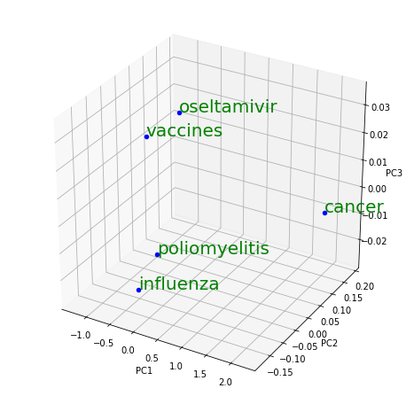

```python
fig = plt.figure(figsize=(8, 8))
ax = fig.add_subplot(111, projection='3d')

# xs = pca_result[:,0]
# ys = pca_result[:,1]
# zs = pca_result[:,2]
# ax.scatter(xs, ys, zs, marker='^')

m = pca_result

for i in range(5): #plot each point + it's name as text
    ax.scatter(m[i,0], m[i,1], m[i,2], color='b')
    ax.text(m[i,0], m[i,1], m[i,2], '%s' % (embed_df.index[i]), size=20, zorder=1, color='g')

ax.set_xlabel('PC1')
ax.set_ylabel('PC2')
ax.set_zlabel('PC3')

plt.show()
```

### Trying out another popular dimensionality reduction technique t-SNE

#### Note: It's important to play around with the parameters for t-SNE, as different values can produce very different results

- n_components (default: 2): Dimension of the embedded space.
- perplexity (default: 30): The perplexity is related to the number of nearest neighbors that are used in other manifold learning algorithms. Consider selecting a value between 5 and 50.

```python
from sklearn.manifold import TSNE
import time
time_start = time.time()

tsne_m = TSNE(n_components=3, init='random', random_state=10, perplexity=30).fit_transform(embed_df)

print('t-SNE done! Time elapsed: {} seconds'.format(time.time()-time_start))
```

```
t-SNE done! Time elapsed: 0.13064002990722656 seconds
```

```python
tsne_m
```

```
array([[ 212.66841 ,   67.99365 , -164.99146 ],
       [-212.18765 ,  -30.711409,  419.16486 ],
       [-304.4197  ,  190.68092 ,  -37.959995],
       [  22.250778,  -17.882713, -619.5142  ],
       [  62.010532, -322.91235 ,  104.628105]], dtype=float32)
```

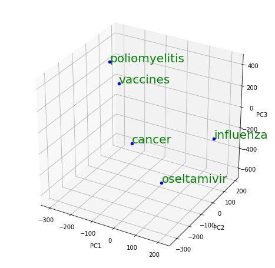

```python
fig = plt.figure(figsize=(8, 8))
ax = fig.add_subplot(111, projection='3d')

m = tsne_m

for i in range(5): #plot each point + it's name as text
    ax.scatter(m[i,0], m[i,1], m[i,2], color='b')
    ax.text(m[i,0], m[i,1], m[i,2], '%s' % (embed_df.index[i]), size=20, zorder=1, color='g')

ax.set_xlabel('PC1')
ax.set_ylabel('PC2')
ax.set_zlabel('PC3')

plt.show()
```

### Alternatively, A combination of PCA and t-SNE could also be helpful citing Scikit-learn's documentation of t-SNE:

#### It is highly recommended to use another dimensionality reduction method (e.g. PCA for dense data or TruncatedSVD for sparse data) to reduce the number of dimensions to a reasonable amount (e.g. 50) if the number of features is very high. This will suppress some noise and speed up the computation of pairwise distances between samples.

### Reading the complete annotation results file into pandas to extract entities classes such as disease, drugs, gene/protein, etc

```python
df3 = pd.read_table("annotation_results_all_jan2016.txt", header=0, encoding='latin1')
df3.head(10)
```

|  | amId | assignedId | sdocId | userId | editorUserId | indexActionMentionId | external_id | dbActionMentionId | entity1 | semantic_class_entity1 | ... | topic | statement_context | negative | certainty_level | derived_certainty_level | applied_rule | indexSentenceId | pmid | sentenceText | procset |
| --- | --- | --- | --- | --- | --- | --- | --- | --- | --- | --- | --- | --- | --- | --- | --- | --- | --- | --- | --- | --- | --- |
| 0 | 44403 | 2 | 12.0 | 6 | 10.0 | NaN | 0.0 | NaN | asd | NaN | ... | NaN | NaN | 0.0 | NaN | NaN | NaN | gw60_biochmbiophyrescomm_295_4_1027_s_40 | 12127999.0 | `Microsomal` membrane prepared as described fr... | bind |
| 1 | 1040 | 3 | 12.0 | 7 | 10.0 | NaN | 0.0 | NaN | testing | NaN | ... | NaN | NaN | NaN | NaN | NaN | NaN | gw60_biochmbiophyrescomm_295_4_1027_s_40 | 12127999.0 | `Microsomal` membrane prepared as described fr... | bind |
| 2 | 57771 | 1 | 201.0 | 5 | NaN | NaN | 0.0 | NaN | Amph2 | GP | ... | NaN | NaN | 0.0 | NaN | NaN | NaN | gw60_embo_17_18_5273_s_218 | 9736607.0 | ( A) Amph2 SH3 and Amph2-SH3deltaDAPS domains ... | bind |
| 3 | 57772 | 2 | 201.0 | 5 | NaN | NaN | 0.0 | NaN | Amph2 | GP | ... | NaN | NaN | 0.0 | NaN | NaN | NaN | gw60_embo_17_18_5273_s_218 | 9736607.0 | ( A) Amph2 SH3 and Amph2-SH3deltaDAPS domains ... | bind |
| 4 | 1108 | 1 | 201.0 | 6 | NaN | NaN | 0.0 | NaN | Amph2 | GP | ... | NaN | NaN | NaN | NaN | NaN | NaN | gw60_embo_17_18_5273_s_218 | 9736607.0 | ( A) Amph2 SH3 and Amph2-SH3deltaDAPS domains ... | bind |
| 5 | 1109 | 2 | 201.0 | 6 | NaN | NaN | 0.0 | NaN | Amph2 | GP | ... | NaN | NaN | NaN | NaN | NaN | NaN | gw60_embo_17_18_5273_s_218 | 9736607.0 | ( A) Amph2 SH3 and Amph2-SH3deltaDAPS domains ... | bind |
| 6 | 57773 | 1 | 212.0 | 5 | NaN | NaN | 0.0 | NaN | Bcl-2 | GP | ... | NaN | in vitro | NaN | NaN | NaN | NaN | gw60_jbiolchem_270_20_11962_s_8 | 7744846.0 | ( A) and an NH -terminal deletion mutant Bcl-... | bind |
| 7 | 57774 | 2 | 212.0 | 5 | NaN | NaN | 0.0 | NaN | Bax | GP | ... | NaN | yeast | NaN | NaN | NaN | NaN | gw60_jbiolchem_270_20_11962_s_8 | 7744846.0 | ( A) and an NH -terminal deletion mutant Bcl-... | bind |
| 8 | 57775 | 3 | 212.0 | 5 | NaN | NaN | 0.0 | NaN | Bcl-2 | GP | ... | NaN | yeast | NaN | NaN | NaN | NaN | gw60_jbiolchem_270_20_11962_s_8 | 7744846.0 | ( A) and an NH -terminal deletion mutant Bcl-... | bind |
| 9 | 1110 | 1 | 212.0 | 6 | NaN | NaN | 0.0 | NaN | Bcl-2 | GP | ... | NaN | In vitro | NaN | NaN | NaN | NaN | gw60_jbiolchem_270_20_11962_s_8 | 7744846.0 | ( A) and an NH -terminal deletion mutant Bcl-... | bind |

10 rows × 31 columns

```python
# top 10 entity classes for entity1
df3.semantic_class_entity1.value_counts()[:10]
```

```
GP                   26842
Process              23796
MedicalFinding       15867
Chemical             12886
BiologicalProcess     8059
MolecularProcess      7725
Protein               7338
Quantity              7031
ResearchActivity      6554
MedicalProcedure      6336
Name: semantic_class_entity1, dtype: int64
```

```
Text(0.5,1,'Frequency for each label in the entity1 column')
```

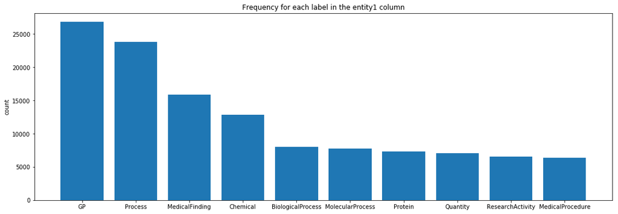

```python
# frequency bar plot for the top 10 classes (entity1)
sem1 = df3.semantic_class_entity1.value_counts()[:10]
plt.figure(figsize=(18, 6))
plt.bar(sem1.index, sem1.values)
plt.ylabel('count')
plt.title('Frequency for each label in the entity1 column')
```

```
Text(0.5,1,'Frequency for each label in the entity2 column')
```

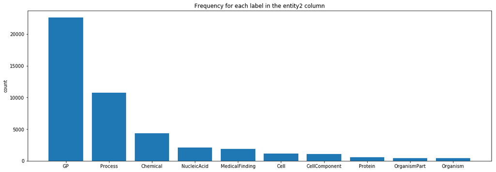

```python
# frequency bar plot for the top 10 classes (entity2)
sem2 = df3.semantic_class_entity2.value_counts()[:10]
plt.figure(figsize=(18, 6))
plt.bar(sem2.index, sem2.values)
plt.ylabel('count')
plt.title('Frequency for each label in the entity2 column')
```

#### Extracting entities with label = 'drug'

```python
# total number of tokens labeled 'Drug' in the entity1 column
sum(df3.semantic_class_entity1 == 'Drug')
```

```
2516
```

```python
# no tokens are labeled 'Drug' in the entity2 column
sum(df3.semantic_class_entity2 == 'Drug')
```

```
0
```

```python
df3.loc[df3.semantic_class_entity1 == 'Drug', ['entity1','semantic_class_entity1']]
```

|  | entity1 | semantic_class_entity1 |
| --- | --- | --- |
| 75332 | hypolipidemic drugs | Drug |
| 75834 | tabletted allacil | Drug |
| 75836 | methylthiouracil | Drug |
| 75838 | hexamidine | Drug |
| 75932 | EE/NET 20/500 | Drug |
| ... | ... | ... |
| 361976 | tribendimidine | Drug |
| 361978 | pyrantel pamoate | Drug |
| 362174 | antibiotics | Drug |
| 362246 | monoacetyl-vitexinrhamnoside ( AVR ) | Drug |
| 362664 | drug | Drug |

2516 rows × 2 columns

#### Extracting entities with label = 'disease'

```python
# total number of tokens labeled 'Disease' in the entity1 column
sum(df3.semantic_class_entity1 == 'Disease')
```

```
3940
```

```python
# total number of tokens labeled 'Disease' in the entity2 column
sum(df3.semantic_class_entity2 == 'Disease')
```

```
119
```

```python
df3.loc[(df3.semantic_class_entity1 == 'Disease') | (df3.semantic_class_entity2 == 'Disease') , ['entity1','semantic_class_entity1','entity2','semantic_class_entity2']]
```

|  | entity1 | semantic_class_entity1 | entity2 | semantic_class_entity2 |
| --- | --- | --- | --- | --- |
| 9456 | alveolar rhabdomyosarcoma | Disease | ARMS | Disease |
| 71242 | DRB1 | Gene | rheumatoid arthritis | Disease |
| 71243 | DRB1 | Gene | autism | Disease |
| 71244 | DRB1 | Gene | schizophrenia | Disease |
| 71245 | DRB1*04 alleles | Gene | rheumatoid arthritis | Disease |
| ... | ... | ... | ... | ... |
| 362308 | organic disease | Disease | NaN | NaN |
| 362440 | acute pancreatitis | Disease | NaN | NaN |
| 362546 | fire blight | Disease | NaN | NaN |
| 362552 | non-small-cell disease | Disease | NaN | NaN |
| 362634 | Ehrlich 's ascitic carcinoma | Disease | NaN | NaN |

4043 rows × 4 columns

### create a list of unique drugs

```python
# number of uniques drugs in entity1
# note: no entities labelled 'drug' in entity2
drug_unique = df3.entity1[df3.semantic_class_entity1 == 'Drug'].unique()
len(drug_unique) # number of unique drugs
```

```
1977
```

### create a list of unique diseases

```python
disease_unique_1 = df3.entity1[df3.semantic_class_entity1 == 'Disease'].unique()
len(disease_unique_1)
```

```
2894
```

```python
disease_unique_2 = df3.entity2[df3.semantic_class_entity2 == 'Disease'].unique()
len(disease_unique_2)
```

```
90
```

```python
disease_unique = set(list(disease_unique_1) + list(disease_unique_2))
len(disease_unique) # total number of unique diseases
```

```
2951
```

### Test how many drugs and diseases are represented in our trained word2vec model

- Note: since our text data are tokenized based on whitespace, diseases and drugs entities that contain whitespaces may not be recognized as a whole entity
- one method is take an average of embeddings associated with one drug or disease

```python
disease_in_vocab = []

for _ in disease_unique:
    if _ in model_nero.wv.vocab:
        disease_in_vocab.append(_)

print('number of diseases represented: {}'.format(len(disease_in_vocab)))
```

```
number of diseases represented: 481
```

```python
drug_in_vocab = []

for _ in drug_unique:
    if _ in model_nero.wv.vocab:
        drug_in_vocab.append(_)

print('number of drugs represented: {}'.format(len(drug_in_vocab)))
```

```
number of drugs represented: 694
```

#### we notice that only a fraction of diseases and drugs have embedding representations in our trained word2vec model, which is expected due to the whitespace insides tokens

For instance, the following disease isn't inside the model's vocab; however, their separate tokens are represented. We can represent the disease using the average of two embeddings for two tokens.

```python
'breast cancer' in model_nero.wv.vocab
```

```
False
```

```python
'breast' in model_nero.wv.vocab
```

```
True
```

```python
'cancer' in model_nero.wv.vocab
```

```
True
```

```python
breast_cancer_emb = (model_nero.wv.get_vector('breast') + model_nero.wv.get_vector('cancer')) / 2
```

```python
# most similar tokens to 'breast cancer' by vector
model_nero.wv.similar_by_vector(breast_cancer_emb)
```

```
[('breast', 0.9984266757965088),
 ('cancer', 0.9984034895896912),
 ('cellular', 0.9963013529777527),
 ('primary', 0.9958871006965637),
 ('express', 0.9957299828529358),
 ('ofDermacentor_reticulatus_adult_females', 0.9954755306243896),
 ('still', 0.995079517364502),
 ('repressIL-2_gene', 0.9950653910636902),
 ('clear', 0.9949610233306885),
 ('macrophages', 0.9949432611465454)]
```

```python
# Get the entity from our disease vocabulary most similar to 'breast'
model_nero.wv.most_similar_to_given('breast', disease_in_vocab)
```

```
'tumors'
```

```python
# get the entity from our drug vocabulary most similar to 'influenza'
model_nero.wv.most_similar_to_given('influenza', drug_in_vocab)
```

```
'corticosteroids'
```

```python
help(model_nero.wv.most_similar_to_given)
```

```
Help on method most_similar_to_given in module gensim.models.keyedvectors:

most_similar_to_given(entity1, entities_list) method of gensim.models.keyedvectors.Word2VecKeyedVectors instance
    Get the `entity` from `entities_list` most similar to `entity1`.
```